# Molecular Clock Dating of Influenza H3N2

Erik Volz

2022-07-18

# 1 pre-Introduction notes for SISMID module on Reconstructing transmission

This is a vignette from the `treedater` R package by Erik Volz (and the rest of this document is his work, taken from the package files).

When we reconstruct phylogenetic trees with software such as IQtree, raxml, FastTree, PAML or other maximum-likelihood tree reconstruction tools, the branches are typically in units of genetic distance (in substitutions per site). Trees typically do not have a root (though when they are read into R, the `ape` package sometimes interprets them as rooted nonetheless).

In contrast, for reconstructing transmission – either person to person transmission in software like `TransPhylo`, or phylogeographic movements of viruses – we often require a timed phylogenetic tree. This is a rooted phylogenetic tree whose branches are in units of calendar time, not substitutions per site. The root is the oldest node in the tree. Nodes have calendar dates, such that each tip’s date corresponds to the date of collection of the sample corresponding to the tip.

The relationship between the untimed and timed trees is shaped by the molecular clock of the pathogen. This is the model defining how substitutions occur through time. For example, do all branches in the phylogeny evolve at the same rate (a “strict clock”) or not (a “relaxed clock”)? `treedater` can take a tree whose branch lengths are in units of genetic distance and create a tree with a root, whose branches are in units of calendar time, such that the tips line up at their collection dates. To create such a tree, you need to provide the input (genetic distance) tree, the dates of sampling of the tips, and the length of the sequences used to reconstruct the tree. Because you are providing the number of substitutions per site, the tree and the dates, `treedater` can estimate the rate of substitution in calendar time. It can also estimate dates of tips where only a lower and upper bound are provided.

Now we continue with Erik Volz’s vignette file.

# 2 Introduction

`treedater` fits a strict or relaxed molecular clock to a phylogenetic tree and estimates evolutionary rates and times of common ancestry. The calendar time of each sample must be specified (possibly with bounds of uncertainty) and the length of the sequences used to estimate the tree.

`treedater` uses heuristic search to optimise the TMRCAs of a phylogeny and the substitution rate. An uncorrelated relaxed molecular clock accounts for rate variation between lineages of the phylogeny which is parameterised using a Gamma-Poisson mixture model.

To cite:

- E.M. Volz and Frost, S.D.W. (2017) [Scalable relaxed clock phylogenetic dating](https://doi.org/10.1093/ve/vex025). Virus Evolution.

The most basic usage is

```r
dater( tre, sts, s)
```

where

- `tre` is an `ape::phylo` phylogeny,
- `sts` is a named vector of sample times for each tip in `tre`
- `s` is the length of the genetic sequences used to estimate `tre`

## 2.1 Invoking treedater from the command line

-t : file name of tree in newick format  
-s : should be a comma-separated-value file with sample times in format <taxon-id,sample-time> and no header -l : the integer length of sequences in alignment used to construct the tree -o : name of file for saving output

[output not shown]

```r
(tre <- ape::read.tree( system.file( 'extdata', 'flu_h3n2_final_small.treefile', package='treedater') ))
```

```
##
## Phylogenetic tree with 177 tips and 175 internal nodes.
##
## Tip labels:
##   HM628693_2010-03-03, KC883039_2011-04-04, KC882820_2011-01-04, GQ983548_2009-06-22, KF790184_2012-10-05, JX978746_2012-03-19, ...
##
## Unrooted; includes branch lengths.
```

Note that this tree does not have a root, and in the process of fitting a molecular clock, we will estimate the best root location.

```r
seqlen <- 1698 # the length of the HA sequences used to reconstruct the phylogeny
```

To fit the molecular clock, we will need the sample time for each lineage. Note that the date of sampling is incorporated into the name of each lineage, which is common in viral phylogenetics studies. The package includes a convenient function for extracting these dates:

```r
sts <- sampleYearsFromLabels( tre$tip.label, delimiter='_' )
head(sts)
```

```
## HM628693_2010-03-03 KC883039_2011-04-04 KC882820_2011-01-04 GQ983548_2009-06-22
##            2010.167            2011.255            2011.008            2009.471
## KF790184_2012-10-05 JX978746_2012-03-19
##            2012.760            2012.213
```

How are samples distributed through time?

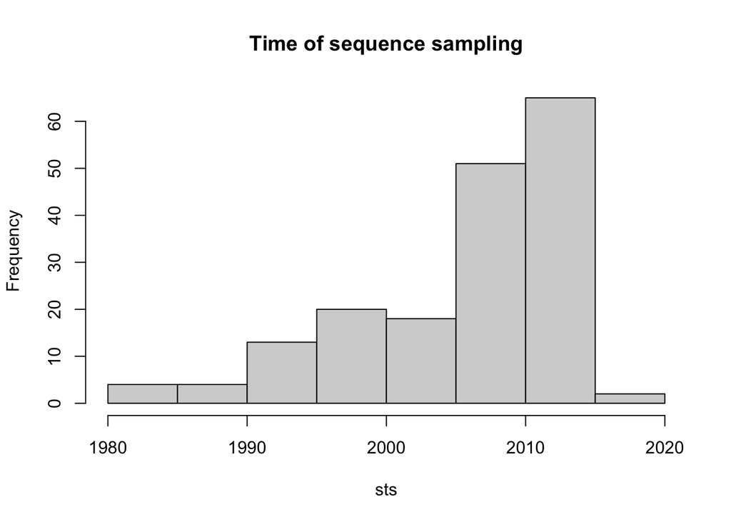

```r
hist( sts , main = 'Time of sequence sampling')
```

The basic usage of the treedater algorithm is as follows:

```r
dtr <- dater( tre , sts, seqlen, clock = 'strict' )
```

[output not shown]

```r
dtr
```

```
##
## NOTE: The p values for lineage clock rates show at least one outlying value after adjusting for multiple-testing.  This indicates a poor fit to the data for at least a portion of the phylogenetic tree. To visualize the distribution p-values, use *goodnessOfFitPlot*.
##
##
## The following steps may help to fix or alleviate common problems:
## * Check that the vector of sample times is correctly named and that the units are correct.
## * If passing a rooted tree, make sure that the root position was chosen correctly, or estimate the root position by passing an unrooted tree (e.g. pass ape::unroot(tree))
## * The root position may be poorly estimated. Try increasing the _searchRoot_ parameter in order to test more lineages as potential root positions.
## * The model may be fitted by a relaxed or strict molecular clock. Try changing the _clock_ parameter
## * A poor fit may be due to a small number of lineages with unusual / outlying branch lengths which can occur due to sequencing error or poor alignment. Try the *outlierTips* command to identify and remove these lineages.
## * Check that there is adequate variance in sample times in order to estimate a molecular clock by doing a root-to-tip regression. Try the *rootToTipRegressionPlot* command. If the clock rate can not be reliably estimated, you can fix the value to a range using the _meanRateLimits_ option which wo…
##
## Phylogenetic tree with 177 tips and 176 internal nodes.
##
## Tip labels:
##   HM628693_2010-03-03, KC883039_2011-04-04, KC882820_2011-01-04, GQ983548_2009-06-22, KF790184_2012-10-05, JX978746_2012-03-19, ...
##
## Rooted; includes branch lengths.
##
##  Time of common ancestor
## 1980.50299575072
##
##  Time to common ancestor (before most recent sample)
## 34.5408398657212
##
##  Weighted mean substitution rate (adjusted by branch lengths)
## 0.00321337949455105
##
##  Unadjusted mean substitution rate
## 0.00321337949455105
##
##  Clock model
## strict
##
##  Coefficient of variation of rates
## 0
```

This produces a *rooted* tree with branches in calendar time. Note that if we invoked `dater` with a rooted input tree, it would *not* estimate the root position. In this way, you can also set the root location in other ways, such as by using an outgroup. It is also good practice to provide at least one initial guess of the substitution rate using the `omega0` parameter, but if we omit that value as we have done here, treedater will attempt to guess good starting values. You can also specify an uncorrelated relaxed clock using `clock='uncorrelated'`.

Lets see how long it takes to run treedater:

```r
rt0 <- Sys.time()
dtr <- dater( tre , sts, seqlen, clock = 'strict' )
```

[output not shown]

```r
rt1 <- Sys.time()
rt1 - rt0
```

```
## Time difference of 14.35145 secs
```

You can speed up treedater by providing a rooted tree, or by providing an educated guess of the substitution rate, or by using parallel computing with the `ncpu` option.

Note the returned value includes estimated substition rates and TMRCAs. The `dtr` object extends `ape::phylo`, so most of the methods that you can use in other R packages that use that format can also be used with a `dater` object. Lets plot the tree.

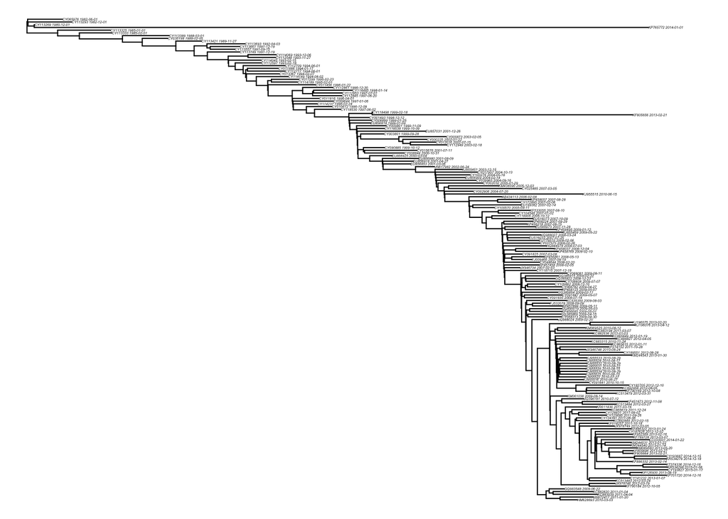

```r
plot( dtr , no.mar=T, cex = .2 )
```

It looks like there are a couple of recent lineages that don’t seem to fit well with the ladder-like topology. We can further examine this by doing a root-to-tip regression using the fitted tree and estimated node times which also shows a couple of outliers:

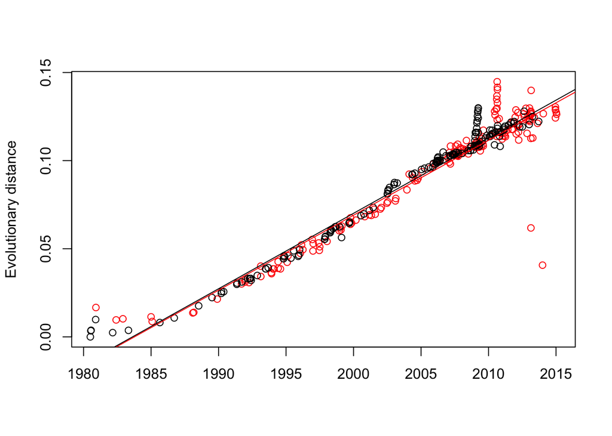

```
## Root-to-tip mean rate: 0.00425285389037381
## Root-to-tip p value: 1.48110816750185e-89
## Root-to-tip R squared (variance explained): 0.900346071590208
## Returning fitted linear model.
```

```r
rootToTipRegressionPlot( dtr )
```

It is always a good idea to visualize these distances to ensure that there is enough ‘clock signal’ in the data to reliably estimate rates and dates. We will examine these outliers in the next section.

## 2.2 Detecting and removing outliers / testing for relaxed clock

To find lineages that dont fit the molecular clock model very well, run

```r
outliers <- outlierTips( dtr , alpha = 0.20)
```

```
##                                   taxon            q            p loglik
## CY118498_1999-02-18 CY118498_1999-02-18 0.000000e+00 0.000000e+00     NA
## KP765772_2014-01-01 KP765772_2014-01-01 4.313748e-27 4.874292e-29     NA
## KF805656_2013-02-21 KF805656_2013-02-21 2.547166e-20 4.317231e-22     NA
## CY113269_1980-12-01 CY113269_1980-12-01 9.825474e-15 2.220446e-16     NA
## KF805696_2013-02-27 KF805696_2013-02-27 2.952830e-10 8.341328e-12     NA
## KJ955531_2010-08-22 KJ955531_2010-08-22 2.342659e-06 7.941217e-08     NA
## KM061038_2009-08-14 KM061038_2009-08-14 7.035534e-04 3.179903e-05     NA
## KJ955515_2010-06-15 KJ955515_2010-06-15 7.035534e-04 2.830968e-05     NA
## KC883315_2010-11-24 KC883315_2010-11-24 1.509124e-03 7.673513e-05     NA
## KJ955534_2010-08-29 KJ955534_2010-08-29 2.048218e-03 1.157185e-04     NA
## KJ955532_2010-08-29 KJ955532_2010-08-29 1.379923e-02 8.575790e-04     NA
## JX978749_2012-03-05 JX978749_2012-03-05 5.510527e-02 4.047279e-03     NA
## EU516033_2007-07-25 EU516033_2007-07-25 5.510527e-02 3.844844e-03     NA
## JQ396181_2010-07-12 JQ396181_2010-07-12 1.499229e-01 1.355235e-02     NA
## KJ955533_2010-08-29 KJ955533_2010-08-29 1.499229e-01 1.200609e-02     NA
## KC865649_2012-01-19 KC865649_2012-01-19 1.499229e-01 1.353763e-02     NA
##                           rates branch.length
## CY118498_1999-02-18 0.003213379    0.01928166
## KP765772_2014-01-01 0.003213379   33.10398111
## KF805656_2013-02-21 0.003213379   14.02750084
## CY113269_1980-12-01 0.003213379    0.01928166
## KF805696_2013-02-27 0.003213379    0.52159511
## KJ955531_2010-08-22 0.003213379    1.40196192
## KM061038_2009-08-14 0.003213379    0.90392304
## KJ955515_2010-06-15 0.003213379    7.42055007
## KC883315_2010-11-24 0.003213379    1.87159441
## KJ955534_2010-08-29 0.003213379    1.42114000
## KJ955532_2010-08-29 0.003213379    1.42114000
## JX978749_2012-03-05 0.003213379    1.87926882
## EU516033_2007-07-25 0.003213379    1.14199367
## JQ396181_2010-07-12 0.003213379    1.18959540
## KJ955533_2010-08-29 0.003213379    1.42114000
## KC865649_2012-01-19 0.003213379    3.06344764
```

This returns a table in ascending order showing the quality of the molecular clock model fit for each lineage. Now lineages could be selected for removal in various ways. Lets remove all tips that dont have a very high q-value :

```r
tre2 <- ape::drop.tip( tre, rownames(outliers[outliers$q < 0.20,]) )
```

Now we can rerun `dater` with the reduced tree:

```r
dtr2 <- dater(tre2, sts, seqlen, clock='uncorrelated', ncpu = 1)  # increase ncpu to use parallel computing
```

```
## Note: Initial guess of substitution rate not provided. Will attempt to guess starting conditions. Provide initial guesses of the rate using *omega0* parameter.
## Note: Minimum temporal branch length  (*minblen*) set to 0.0202671658300009. Increase *minblen* in the event of convergence failures.
## Tree is not rooted. Searching for best root position. Increase searchRoot to try harder.
## Initial guesses of substitution rate: 0.00428031122099498,0.00428031331175239,0.00444300982149261,0.00444301188242019,0.00460570842199024,0.00460571045308799
## Initial guesses of substitution rate: 0.00428031331175239,0.00428186446258192,0.00444301188242019,0.00444542080547683,0.00460571045308799,0.00460897714837174
## Initial guesses of substitution rate: 0.00424585532272424,0.00428031331175238,0.00441183237609377,0.00444301188242018,0.00457780942946329,0.00460571045308799
## Initial guesses of substitution rate: 0.00419969857588737,0.00428031331175239,0.00437920537947406,0.00444301188242019,0.00455871218306076,0.00460571045308799
## Initial guesses of substitution rate: 0.00417281469848489,0.00428031331175239,0.00435352237986441,0.00444301188242019,0.00453423006124393,0.00460571045308799
```

```r
dtr2
```

```
##
## Phylogenetic tree with 161 tips and 160 internal nodes.
##
## Tip labels:
##   HM628693_2010-03-03, KC883039_2011-04-04, KC882820_2011-01-04, GQ983548_2009-06-22, KF790184_2012-10-05, JX978746_2012-03-19, ...
##
## Rooted; includes branch lengths.
##
##  Time of common ancestor
## 1981.64612990573
##
##  Time to common ancestor (before most recent sample)
## 33.3977057107095
##
##  Weighted mean substitution rate (adjusted by branch lengths)
## 0.00410532691156498
##
##  Unadjusted mean substitution rate
## 0.00435527382447602
##
##  Clock model
## uncorrelated
##
##  Coefficient of variation of rates
## 0.0983473593638527
```

```r
rct <- relaxedClockTest( tre2, sts, seqlen, ncpu = 1 ) # increase ncpu to use parallel computing
```

[output not shown]

This test indicates a relaxed clock. Nevertheless, lets re-fit the model to the reduced tree using a strict clock for comparison:

```r
dtr3 <- dater( tre2, sts, seqlen, clock='strict' )
```

```
## Note: Initial guess of substitution rate not provided. Will attempt to guess starting conditions. Provide initial guesses of the rate using *omega0* parameter.
## Note: Minimum temporal branch length  (*minblen*) set to 0.0202671658300009. Increase *minblen* in the event of convergence failures.
## Tree is not rooted. Searching for best root position. Increase searchRoot to try harder.
## Initial guesses of substitution rate: 0.00428031122099498,0.00428031331175239,0.00444300982149261,0.00444301188242019,0.00460570842199024,0.00460571045308799
## Initial guesses of substitution rate: 0.00428031331175239,0.00428186446258192,0.00444301188242019,0.00444542080547683,0.00460571045308799,0.00460897714837174
## Initial guesses of substitution rate: 0.00424585532272424,0.00428031331175238,0.00441183237609377,0.00444301188242018,0.00457780942946329,0.00460571045308799
## Initial guesses of substitution rate: 0.00419969857588737,0.00428031331175239,0.00437920537947406,0.00444301188242019,0.00455871218306076,0.00460571045308799
## Initial guesses of substitution rate: 0.00417281469848489,0.00428031331175239,0.00435352237986441,0.00444301188242019,0.00453423006124393,0.00460571045308799
```

```r
dtr3
```

```
##
## Phylogenetic tree with 161 tips and 160 internal nodes.
##
## Tip labels:
##   HM628693_2010-03-03, KC883039_2011-04-04, KC882820_2011-01-04, GQ983548_2009-06-22, KF790184_2012-10-05, JX978746_2012-03-19, ...
##
## Rooted; includes branch lengths.
##
##  Time of common ancestor
## 1981.39140639216
##
##  Time to common ancestor (before most recent sample)
## 33.6524292242771
##
##  Weighted mean substitution rate (adjusted by branch lengths)
## 0.00429293702431405
##
##  Unadjusted mean substitution rate
## 0.00429293702431405
##
##  Clock model
## strict
##
##  Coefficient of variation of rates
## 0
```

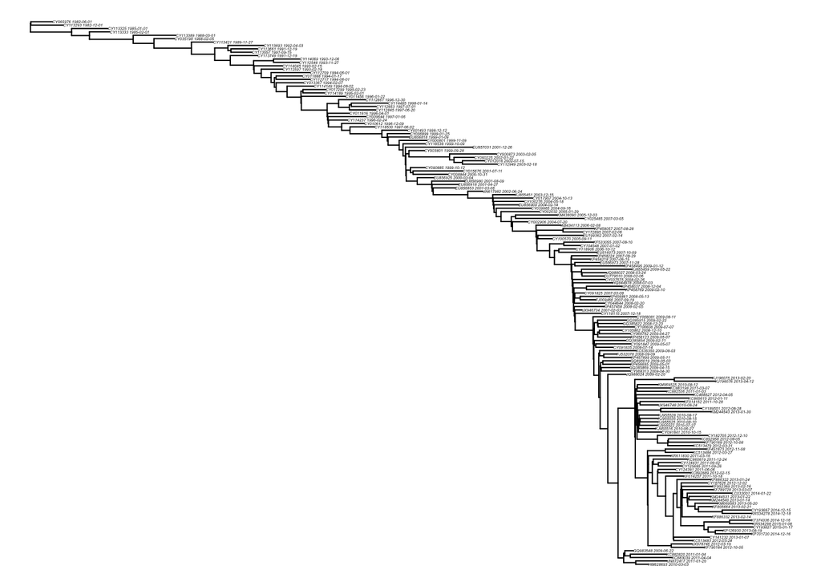

```r
plot( dtr3 , no.mar=T, cex = .2 )
```

## 2.3 Parametric bootstrap

Estimating confidence intervals for rates and dates is straightforward using a parametric bootstrap:

```r
rt2 <- Sys.time()
(pb <- parboot( dtr3, ncpu = 1) )# increase ncpu to use parallel computing
```

```
## Running in quiet mode. To print progress, set quiet=FALSE.
## NOTE: Running with overrideSearchRoot will speed up execution but may underestimate variance.
## NOTE: Running with overrideTempConstraint will speed up execution but may underestimate variance. Bootstrap tree replicates may have negative branch lengths.
```

```
##                            pseudo ML       2.5 %       97.5 %
## Time of common ancestor 1.981391e+03 1.98085e+03 1.981864e+03
## Mean substitution rate  4.292937e-03 3.95059e-03 4.664951e-03
##
##  For more detailed output, $trees provides a list of each fit to each simulation
```

```r
rt3 <- Sys.time()
```

How fast was it? Note that the `ncpu` option would enable parallel computing.

```r
rt3 - rt2
```

```
## Time difference of 51.16751 secs
```

We can also plot the estimated number of lineages through time with confidence intervals:

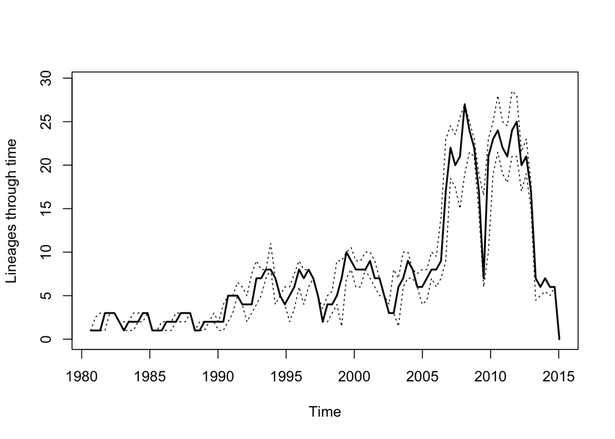

```r
plot( pb )
```

If the *ggplot2* package is installed, we can use that instead:

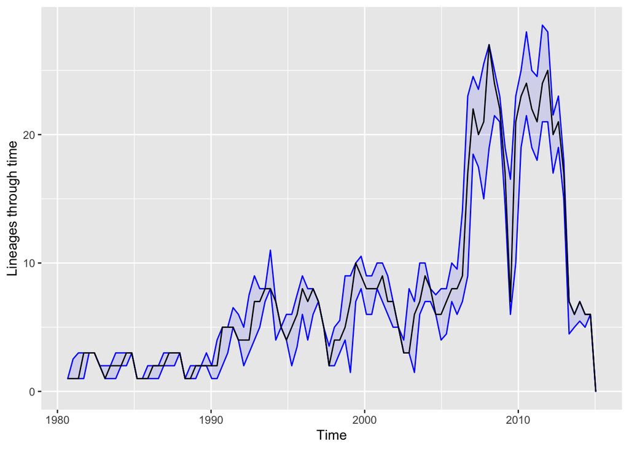

```r
if ( suppressPackageStartupMessages( require(ggplot2)) )
  (pb.pl <- plot( pb , ggplot=TRUE) )
```

Note repeated bottlenecks and seasonal peaks of LTT corresponding to when samples are taken during seasonal epidemics.

The package also includes methods for nonparametric bootstrapping if you have already computed a bootstrap distribution of phylogenies.

## 2.4 Missing sample times

Suppose we only know some of the sample times to the nearest month, a common occurance in viral phylogenetic studies. To simulate this, we will put uncertainty bounds on some sample times equal to a +/- 2-week window. We create the following data frame with columns `lower` and `upper`:

```r
sts.df <- data.frame( lower = sts[1:50] - 15/365, upper = sts[1:50] + 15/365 )
head(sts.df )
```

```
##                        lower    upper
## HM628693_2010-03-03 2010.126 2010.208
## KC883039_2011-04-04 2011.214 2011.296
## KC882820_2011-01-04 2010.967 2011.049
## GQ983548_2009-06-22 2009.430 2009.512
## KF790184_2012-10-05 2012.718 2012.801
## JX978746_2012-03-19 2012.172 2012.254
```

In this case, we constructed the data frame with bounds for the first 50 samples in the tree, but we could also manually construct a data frame for a few selected samples where times of sampling are uncertain, or for all of the samples.

Now re-run treedater with the uncertain sample times. The vector `sts` provided here gives an initial guess of the unknown sample times.

```r
(dtr4 <- dater( tre2, sts, seqlen, clock='strict', estimateSampleTimes = sts.df ) )
```

```
## Note: Initial guess of substitution rate not provided. Will attempt to guess starting conditions. Provide initial guesses of the rate using *omega0* parameter.
## Note: Minimum temporal branch length  (*minblen*) set to 0.0202671658300009. Increase *minblen* in the event of convergence failures.
## Tree is not rooted. Searching for best root position. Increase searchRoot to try harder.
## Initial guesses of substitution rate: 0.00428031122099498,0.00428031331175239,0.00444300982149261,0.00444301188242019,0.00460570842199024,0.00460571045308799
## Initial guesses of substitution rate: 0.00428031331175239,0.00428186446258192,0.00444301188242019,0.00444542080547683,0.00460571045308799,0.00460897714837174
## Initial guesses of substitution rate: 0.00424585532272424,0.00428031331175238,0.00441183237609377,0.00444301188242018,0.00457780942946329,0.00460571045308799
## Initial guesses of substitution rate: 0.00419969857588737,0.00428031331175239,0.00437920537947406,0.00444301188242019,0.00455871218306076,0.00460571045308799
## Initial guesses of substitution rate: 0.00417281469848489,0.00428031331175239,0.00435352237986441,0.00444301188242019,0.00453423006124393,0.00460571045308799
```

```
##
## Phylogenetic tree with 161 tips and 160 internal nodes.
##
## Tip labels:
##   HM628693_2010-03-03, KC883039_2011-04-04, KC882820_2011-01-04, GQ983548_2009-06-22, KF790184_2012-10-05, JX978746_2012-03-19, ...
##
## Rooted; includes branch lengths.
##
##  Time of common ancestor
## 1981.40756794937
##
##  Time to common ancestor (before most recent sample)
## 33.6526189829181
##
##  Weighted mean substitution rate (adjusted by branch lengths)
## 0.00432263525320019
##
##  Unadjusted mean substitution rate
## 0.00432263525320019
##
##  Clock model
## strict
##
##  Coefficient of variation of rates
## 0
```

Note that the estimated rates and dates didn’t change very much due to uncertain sample dates in this case.